# ML Prediction Assignment Writeup

fastboatstR

7/16/2017

```r
# knitr::opts_chunk$set(echo = TRUE, fig.width=12, fig.height=8, results = 'asis')
knitr::opts_chunk$set(echo = TRUE, results = 'asis')
require(caret)
require(dplyr)
require(ggplot2)
require(readr)
require(moments)
require(knitr)
require(RANN)
require(klaR)
# set seed:
set.seed(2017)
```

## Exploratory Analysis

First, we loaded ‘pml_training’ dataset and determined its number of rows:

```r
pml_training <- read_csv("~/ml_final_proj/pml-training.csv",
    col_types = cols(X1 = col_skip()))
# output number of rows:
cat(nrow(pml_training))
```

19622

We need to inspect the dataset to determine the number of columns and whether there are any obvious features like empty columns etc:

```r
# number of rows
cat(ncol(pml_training))
```

159

```r
# # dataset summary
# summary(pml_training)
```

There are 159 columns, but we noticed that many of these appear to be empty and will not be useful to build our prediction model(s):

```r
# datset's column names
col_names <- colnames(pml_training)
# vector of blank columns with either "" or NAs:
blank_vec <- sapply(pml_training, function(x) all(x == "" || is.na(x)))
blank_cols <- col_names[blank_vec]
n_blanks <- length(blank_cols)
```

We have 100 empty columns:

kurtosis_roll_belt, kurtosis_picth_belt, kurtosis_yaw_belt, skewness_roll_belt, skewness_roll_belt.1, skewness_yaw_belt, max_roll_belt, max_picth_belt, max_yaw_belt, min_roll_belt, min_pitch_belt, min_yaw_belt, amplitude_roll_belt, amplitude_pitch_belt, amplitude_yaw_belt, var_total_accel_belt, avg_roll_belt, stddev_roll_belt, var_roll_belt, avg_pitch_belt, stddev_pitch_belt, var_pitch_belt, avg_yaw_belt, stddev_yaw_belt, var_yaw_belt, var_accel_arm, avg_roll_arm, stddev_roll_arm, var_roll_arm, avg_pitch_arm, stddev_pitch_arm, var_pitch_arm, avg_yaw_arm, stddev_yaw_arm, var_yaw_arm, kurtosis_roll_arm, kurtosis_picth_arm, kurtosis_yaw_arm, skewness_roll_arm, skewness_pitch_arm, skewness_yaw_arm, max_roll_arm, max_picth_arm, max_yaw_arm, min_roll_arm, min_pitch_arm, min_yaw_arm, amplitude_roll_arm, amplitude_pitch_arm, amplitude_yaw_arm, kurtosis_roll_dumbbell, kurtosis_picth_dumbbell, kurtosis_yaw_dumbbell, skewness_roll_dumbbell, skewness_pitch_dumbbell, skewness_yaw_dumbbell, max_roll_dumbbell, max_picth_dumbbell, max_yaw_dumbbell, min_roll_dumbbell, min_pitch_dumbbell, min_yaw_dumbbell, amplitude_roll_dumbbell, amplitude_pitch_dumbbell, amplitude_yaw_dumbbell, var_accel_dumbbell, avg_roll_dumbbell, stddev_roll_dumbbell, var_roll_dumbbell, avg_pitch_dumbbell, stddev_pitch_dumbbell, var_pitch_dumbbell, avg_yaw_dumbbell, stddev_yaw_dumbbell, var_yaw_dumbbell, kurtosis_roll_forearm, kurtosis_picth_forearm, kurtosis_yaw_forearm, skewness_roll_forearm, skewness_pitch_forearm, skewness_yaw_forearm, max_roll_forearm, max_picth_forearm, max_yaw_forearm, min_roll_forearm, min_pitch_forearm, min_yaw_forearm, amplitude_roll_forearm, amplitude_pitch_forearm, amplitude_yaw_forearm, var_accel_forearm, avg_roll_forearm, stddev_roll_forearm, var_roll_forearm, avg_pitch_forearm, stddev_pitch_forearm, var_pitch_forearm, avg_yaw_forearm, stddev_yaw_forearm, var_yaw_forearm

These can be removed from training dataset to make further exploration easier:

```r
# remove blank columns and explore this dataframe:
new_ds <- pml_training[,-which(names(pml_training) %in% blank_cols)]
# new_ds <- pml_training %>% select(-one_of(blank_cols))
# summary(new_ds)
```

Also, we have columns with some NA values, which will need to be imputed:

```r
na_cols <- apply(new_ds, 2, function(x) any(is.na(x)))
which(na_cols == TRUE)
```

magnet_dumbbell_z magnet_forearm_y magnet_forearm_z 45 57 58

Let’s determine if any columns have highly skewed data:

```r
# calculate skewness
skewnesses <- unlist(sapply(new_ds, function(x) {if (is.numeric(x)) skewness(x)}))
high_skew_vec <- which(skewnesses < -2 | skewnesses > 2)
# output a table of columns with high skewness
skewd <- skewnesses[high_skew_vec]
skewd
```

magnet_belt_y gyros_dumbbell_x gyros_dumbbell_y gyros_dumbbell_z -2.236012 -126.330878 31.650693 135.963831 gyros_forearm_y gyros_forearm_z 51.327716 116.085068

Indeed, several columns like *gyros_dumbbell_z* or *gyros_dumbbell_x* have highly skewed data:

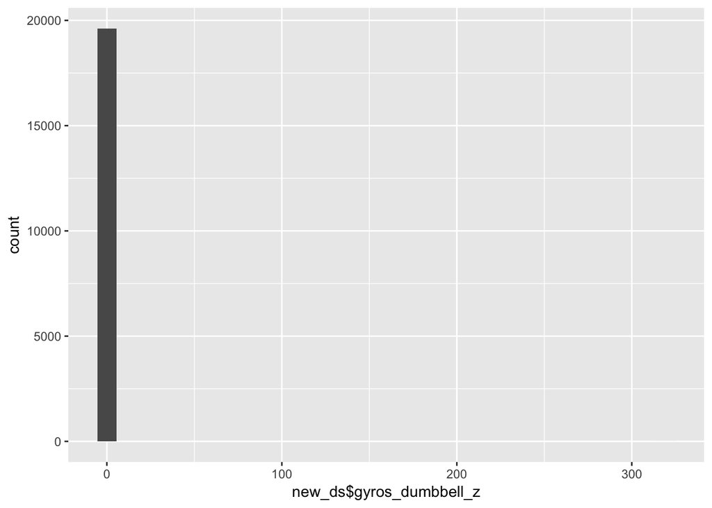

**Figure 1.** gyros_dumbbell_z column values distribution

```r
qplot(new_ds$gyros_dumbbell_z, geom="histogram")
```

This indicates that data preprocessing would have been required if generalized linear model (glm) was to be used for prediction. However, *train* function doesn’t allow to have more than 2 classes of predicted variable if *glm* model is used.

## Model Training/Cross-Validation

```r
# define training control (set cross-validation parameters, in this case 10-fold)
tc <- trainControl(method="repeatedcv", number=10, repeats=3, search="random")
# prepare dataframe of features
new_ds2 <- subset(new_ds, select= -classe)
new_ds3 <- as.data.frame(new_ds2)
# prepare vector of results
res <- as.factor(new_ds$classe)
```

```r
# random-forest model
rfModel <- train(x = new_ds3, y = res, method = "rpart",
                 preProcess = "knnImpute",
                 metric='Accuracy', tuneLength=15,
                 trControl = tc
                 )
rfModel
```

CART

19622 samples 58 predictor 5 classes: ‘A’, ‘B’, ‘C’, ‘D’, ‘E’

Pre-processing: nearest neighbor imputation (55), ignore (3), centered (55), scaled (55) Resampling: Cross-Validated (10 fold, repeated 3 times) Summary of sample sizes: 17659, 17660, 17659, 17659, 17661, 17660, … Resampling results across tuning parameters:

cp Accuracy Kappa  
0.0002136448 0.9878370 0.9846161 0.0004272896 0.9857474 0.9819728 0.0008545791 0.9754528 0.9689573 0.0009970090 0.9742294 0.9674091 0.0013530836 0.9697787 0.9617813 0.0017803732 0.9634933 0.9538389 0.0021364478 0.9565960 0.9451092 0.0023500926 0.9546767 0.9426803 0.0027773821 0.9487315 0.9351762 0.0028842045 0.9462682 0.9320770 0.0079048569 0.8949484 0.8671901 0.0089018658 0.8861662 0.8560531 0.0606039026 0.5611197 0.4477926

Accuracy was used to select the optimal model using the largest value. The final value used for the model was cp = 0.0002136448.

```r
# naive bayses model:
nbModel <- train(x = new_ds3, y = res, method = "nb",
                 preProcess = "knnImpute",
                 metric='Accuracy', tuneLength=15,
                 trControl = tc
                 )
nbModel
```

[output not shown]

## Out-of-sample prediction accuracy estimation for testing dataset

```r
pml_testing <- read_csv("~/ml_final_proj/pml-testing.csv",
    col_types = cols(X1 = col_skip()))
```

Values of *classe* variable were predicted:

```r
# predict classes for test dataset:
predictions <- predict(rfModel, pml_testing)
predictions
```

[1] B A B A A E D B A A B C B A E E A B B B Levels: A B C D E

Accuracy was determined to be 0.9 (as determined by entering predicted values into the grading form).